# Phase 1: Exploratory Data Analysis - S&P SL 20

## Section 7: Time Series Analysis: Individual Stocks

Analyzing top S&P SL 20 stocks over time using pre-calculated moving averages.

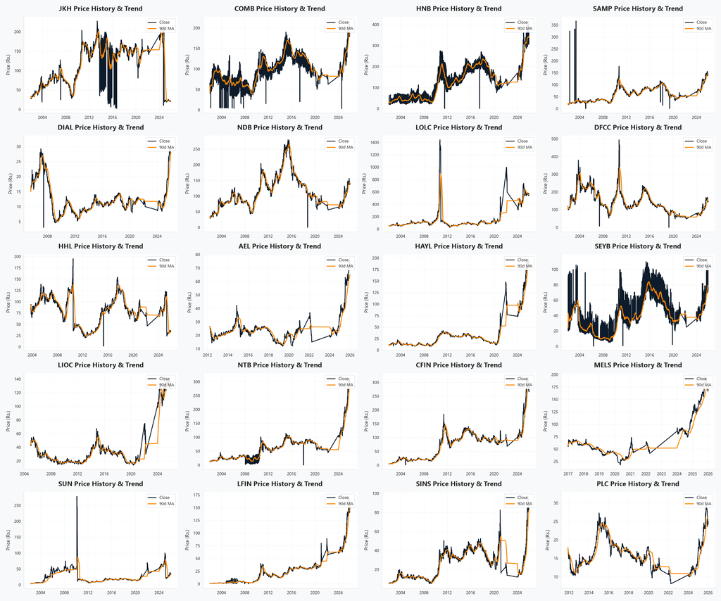

> **Insight - Stocks**: Blue-chip stocks demonstrate clear, prolonged trend phases. The pre-calculated 90-day Moving Average effectively filters out short-term noise, providing a solid baseline for trend detection.

## Section 8: Distribution Analysis

Understanding the statistical properties of S&P SL 20 stock returns.

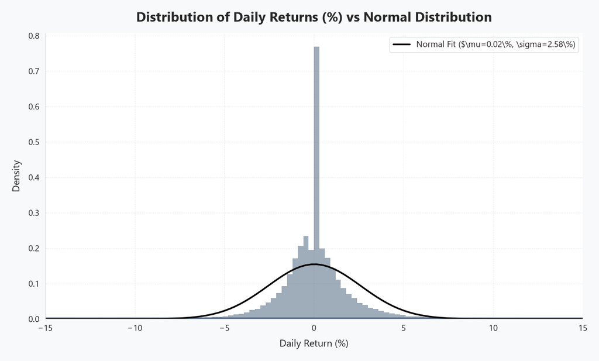

```
Skewness: 126.9980
Kurtosis: 17224.9744
```

> **Insight - Distributions**: Even for highly liquid blue-chip stocks, returns exhibit significant excess kurtosis (fat tails). This implies extreme market moves (both up and down) happen more frequently than a normal bell curve would predict.